# Elements of multiple regression

```r
library(tidyverse)
library(mosaicData)
library(janitor)
```

```r
RailTrail
```

| hightemp | lowtemp | avgtemp | spring | summer | fall | cloudcover | precip | volume | weekday | dayType |
| --- | --- | --- | --- | --- | --- | --- | --- | --- | --- | --- |
| 83 | 50 | 66.5 | 0 | 1 | 0 | 7.6 | 0.00 | 501 | TRUE | weekday |
| 73 | 49 | 61.0 | 0 | 1 | 0 | 6.3 | 0.29 | 419 | TRUE | weekday |
| 74 | 52 | 63.0 | 1 | 0 | 0 | 7.5 | 0.32 | 397 | TRUE | weekday |
| 95 | 61 | 78.0 | 0 | 1 | 0 | 2.6 | 0.00 | 385 | FALSE | weekend |
| 44 | 52 | 48.0 | 1 | 0 | 0 | 10.0 | 0.14 | 200 | TRUE | weekday |
| 69 | 54 | 61.5 | 1 | 0 | 0 | 6.6 | 0.02 | 375 | TRUE | weekday |
| 66 | 39 | 52.5 | 1 | 0 | 0 | 2.4 | 0.00 | 417 | TRUE | weekday |
| 66 | 38 | 52.0 | 1 | 0 | 0 | 0.0 | 0.00 | 629 | FALSE | weekend |
| 80 | 55 | 67.5 | 0 | 1 | 0 | 3.8 | 0.00 | 533 | FALSE | weekend |
| 79 | 45 | 62.0 | 0 | 1 | 0 | 4.1 | 0.00 | 547 | TRUE | weekday |

[output cut: 80 more lines]

```r
railtrail_clean <- RailTrail %>%
  clean_names() %>%
  mutate(across(spring:fall, as.logical))

head(railtrail_clean)
```

|  | hightemp | lowtemp | avgtemp | spring | summer | fall | cloudcover | precip | volume | weekday | day_type |
| --- | --- | --- | --- | --- | --- | --- | --- | --- | --- | --- | --- |
| 1 | 83 | 50 | 66.5 | FALSE | TRUE | FALSE | 7.6 | 0.00 | 501 | TRUE | weekday |
| 2 | 73 | 49 | 61.0 | FALSE | TRUE | FALSE | 6.3 | 0.29 | 419 | TRUE | weekday |
| 3 | 74 | 52 | 63.0 | TRUE | FALSE | FALSE | 7.5 | 0.32 | 397 | TRUE | weekday |
| 4 | 95 | 61 | 78.0 | FALSE | TRUE | FALSE | 2.6 | 0.00 | 385 | FALSE | weekend |
| 5 | 44 | 52 | 48.0 | TRUE | FALSE | FALSE | 10.0 | 0.14 | 200 | TRUE | weekday |
| 6 | 69 | 54 | 61.5 | TRUE | FALSE | FALSE | 6.6 | 0.02 | 375 | TRUE | weekday |

```r
railtrail_trim <- railtrail_clean %>%
  select(-c("hightemp", "lowtemp", "fall", "day_type"))

head(railtrail_trim)
```

|  | avgtemp | spring | summer | cloudcover | precip | volume | weekday |
| --- | --- | --- | --- | --- | --- | --- | --- |
| 1 | 66.5 | FALSE | TRUE | 7.6 | 0.00 | 501 | TRUE |
| 2 | 61.0 | FALSE | TRUE | 6.3 | 0.29 | 419 | TRUE |
| 3 | 63.0 | TRUE | FALSE | 7.5 | 0.32 | 397 | TRUE |
| 4 | 78.0 | FALSE | TRUE | 2.6 | 0.00 | 385 | FALSE |
| 5 | 48.0 | TRUE | FALSE | 10.0 | 0.14 | 200 | TRUE |
| 6 | 61.5 | TRUE | FALSE | 6.6 | 0.02 | 375 | TRUE |

```r
alias(lm(volume ~ . , data = railtrail_clean))
```

```
Model :
volume ~ hightemp + lowtemp + avgtemp + spring + summer + fall +
    cloudcover + precip + weekday + day_type

Complete :
                (Intercept) hightemp lowtemp springTRUE summerTRUE cloudcover precip weekdayTRUE
avgtemp           0         1/2      1/2       0          0          0          0      0
fallTRUE          1           0        0      -1         -1          0          0      0
day_typeweekend   1           0        0       0          0          0          0     -1
```

```r
alias(lm(volume ~ . , data = railtrail_trim))
```

```
Model :
volume ~ avgtemp + spring + summer + cloudcover + precip + weekday
```

[output not shown]

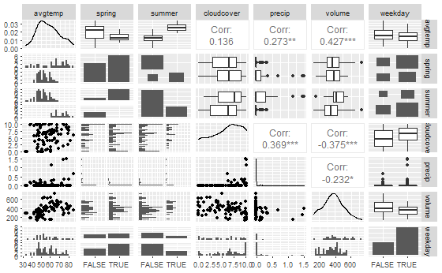

```r
library(GGally)
ggpairs(railtrail_trim)
```

Use this for an idea of what to plot

```r
library(ggfortify)
```

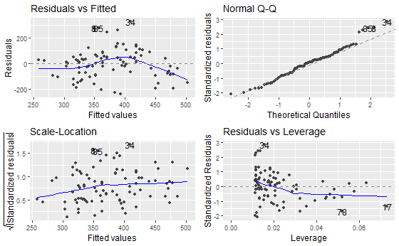

```r
model <- lm(volume ~ avgtemp, data = railtrail_trim)
autoplot(model)
```

```r
summary(model)
```

```
Call:
lm(formula = volume ~ avgtemp, data = railtrail_trim)

Residuals:
    Min      1Q  Median      3Q     Max
-237.53  -80.00    8.49   55.14  326.67

Coefficients:
            Estimate Std. Error t value Pr(>|t|)
(Intercept)   99.602     63.474   1.569     0.12
avgtemp        4.802      1.084   4.428 2.72e-05 ***
---
Signif. codes:  0 ‘***’ 0.001 ‘**’ 0.01 ‘*’ 0.05 ‘.’ 0.1 ‘ ’ 1

Residual standard error: 115.9 on 88 degrees of freedom
Multiple R-squared:  0.1822,    Adjusted R-squared:  0.1729
F-statistic: 19.61 on 1 and 88 DF,  p-value: 2.723e-05
```

Task - 2 mins Check the regression assumptions. How well does this simple model perform in predicting volume? [Hint - remember, we can check the regression assumptions by plotting the model object]

What does the R value tell us about how well it performs?

- Multiple R-squared: 18% (0.1822)
- Residual standard error: 115.9 has a high level of error, for 500 people this could show 385-615 people.

The regression doesn’t seem too bad, although there is some evidence of systematic variation not captured in the Residuals vs Fitted plot, some deviation from normality in the high quantile residuals in the Normal Q-Q plot, and evidence of rather mild heteroscedasticity in the Scale-Location plot.

Alas, however, the model isn’t very effective. The r2 value is 0.18, and the residual standard error is 115.9. To put the latter in context, let’s see the boxplot of volume.

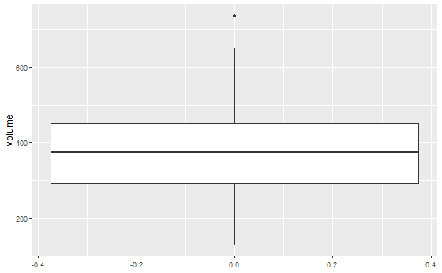

```r
railtrail_trim %>%
  ggplot(aes(y = volume)) +
  geom_boxplot()
```

How do we fix this then? This is where the magic of multiple linear regression comes in. We can hopefully do better by adding further predictors to the model, taking us into the territory of multiple linear regression! Adding predictors might well also fix some of the rather mild breaches of the regression assumptions we have observed. Fingers crossed!

# Add in another Variable

```r
model2 <- lm(volume ~ avgtemp + weekday, data = railtrail_trim)

summary(model2)
```

```
Call:
lm(formula = volume ~ avgtemp + weekday, data = railtrail_trim)

Residuals:
    Min      1Q  Median      3Q     Max
-242.92  -75.72    3.15   66.90  280.06

Coefficients:
            Estimate Std. Error t value Pr(>|t|)
(Intercept)  163.022     65.428   2.492  0.01461 *
avgtemp        4.541      1.050   4.323 4.08e-05 ***
weekdayTRUE  -70.320     25.566  -2.751  0.00724 **
---
Signif. codes:  0 ‘***’ 0.001 ‘**’ 0.01 ‘*’ 0.05 ‘.’ 0.1 ‘ ’ 1

Residual standard error: 111.8 on 87 degrees of freedom
Multiple R-squared:  0.2476,    Adjusted R-squared:  0.2303
F-statistic: 14.32 on 2 and 87 DF,  p-value: 4.214e-06
```

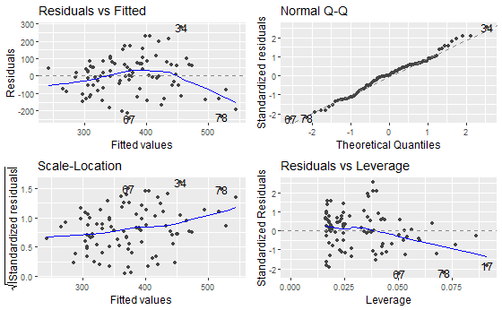

```r
autoplot(model2)
```

- weekdayTRUE -70.320: There are approx 70 fewer users on the trail each weekday as compares with the weekend (with avg temp held constant)
- Pr is the P-value

```r
library(mosaic)
```

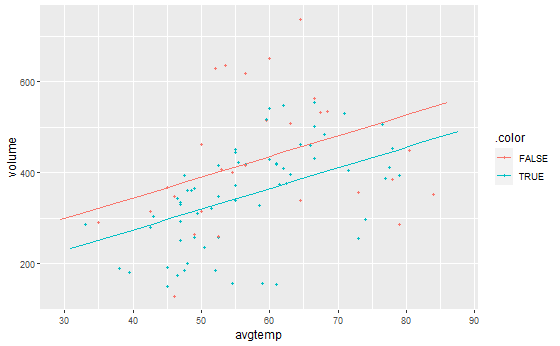

```r
plotModel(model2)
```

So we see the model effectively has *two lines*: one for weekdays, and another for weekend days. The lines are **parallel** (their slopes are the same), so we call this a ‘parallel slopes model’.

How do these two lines come about? Let’s look again at the regression equation:

$$\widehat{\textrm{volume}} = \textrm{intercept} + b_{\textrm{avgtemp}} \times \textrm{avgtemp} + b_{\textrm{weekday}} \times \textrm{weekday}$$

$$\widehat{\textrm{volume}} = (\textrm{intercept} + b_{\textrm{weekday}}) + b_{\textrm{avgtemp}} \times \textrm{avgtemp}$$

i.e. just a shift in the `intercept`, while for `weekday = FALSE` values, we get

$$\widehat{\textrm{volume}} = \textrm{intercept} + b_{\textrm{avgtemp}} \times \textrm{avgtemp}$$

**Task - 5 mins**

Try adding the `summer` categorical predictor to the existing model with `avgtemp` and `weekday`.

$$\widehat{\textrm{volume}} = \textrm{intercept} + b_{\textrm{avgtemp}} \times \textrm{avgtemp} + b_{\textrm{weekday}} \times \textrm{weekday} + b_{\textrm{summer}} \times \textrm{summer}$$

```r
model3 <- lm(volume ~ avgtemp + weekday + summer, data = railtrail_trim)

summary(model3)
```

```
Call:
lm(formula = volume ~ avgtemp + weekday + summer, data = railtrail_trim)

Residuals:
     Min       1Q   Median       3Q      Max
-236.165  -75.448    6.184   68.496  252.680

Coefficients:
            Estimate Std. Error t value Pr(>|t|)
(Intercept)   71.376     90.336   0.790 0.431630
avgtemp        6.387      1.639   3.898 0.000192 ***
weekdayTRUE  -66.958     25.505  -2.625 0.010244 *
summerTRUE   -59.977     41.052  -1.461 0.147662
---
Signif. codes:  0 ‘***’ 0.001 ‘**’ 0.01 ‘*’ 0.05 ‘.’ 0.1 ‘ ’ 1

Residual standard error: 111.1 on 86 degrees of freedom
Multiple R-squared:  0.2659,    Adjusted R-squared:  0.2402
F-statistic: 10.38 on 3 and 86 DF,  p-value: 6.714e-06
```

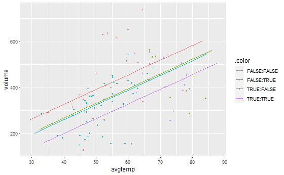

```r
plotModel(model3)
```

We find four parallel lines, as expected! However, we’ll leave summer out of the model, as the p-value of its coefficient indicates that it is not significant.

# Interactions

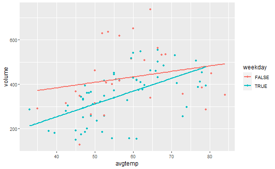

```r
railtrail_trim %>%
  ggplot(aes(x = avgtemp, y = volume, color = weekday)) +
  geom_point() +
  geom_smooth(method = "lm", se = FALSE)
```

How do we interpret this? What we see is equivalent to grouping the data by `weekday` and obtaining best-fit lines of `volume` versus `avgtemp` for each group of data independently. It’s clear that **the slopes and intercepts of these best-fit lines vary depending on whether `weekday` is `TRUE` or `FALSE`**.

How can we add this behaviour into our model? By adding an **interaction** between `avgtemp` and `weekday`.

$$\widehat{\textrm{volume}} = \textrm{intercept} + b_{\textrm{avgtemp}} \times \textrm{avgtemp} + b_{\textrm{weekday}} \times \textrm{weekday} + b_{\textrm{avgtemp:weekday}} \times \textrm{avgtemp} \times \textrm{weekday}$$

The last term here is the interaction. Notice that it involves the **product** of the two predictors: $\textrm{avgtemp} \times \textrm{weekday}$.

We do this in `patsy` formula notation with the $:$ operator as follows:

```r
model4 <- lm(volume ~ avgtemp + weekday + avgtemp:weekday, data = railtrail_trim)

summary(model4)
```

```
Call:
lm(formula = volume ~ avgtemp + weekday + avgtemp:weekday, data = railtrail_trim)

Residuals:
     Min       1Q   Median       3Q      Max
-269.906  -78.862    2.064   68.190  291.641

Coefficients:
                    Estimate Std. Error t value Pr(>|t|)
(Intercept)          285.887    103.390   2.765  0.00696 **
avgtemp                2.457      1.718   1.431  0.15619
weekdayTRUE         -262.193    128.181  -2.045  0.04386 *
avgtemp:weekdayTRUE    3.300      2.161   1.527  0.13040
---
Signif. codes:  0 ‘***’ 0.001 ‘**’ 0.01 ‘*’ 0.05 ‘.’ 0.1 ‘ ’ 1

Residual standard error: 111 on 86 degrees of freedom
Multiple R-squared:  0.2675,    Adjusted R-squared:  0.2419
F-statistic: 10.47 on 3 and 86 DF,  p-value: 6.115e-06
```

We can read $:$ as *‘…interacting with…’*, so `+ avgtemp:weekday` can be read as *‘add `avgtemp` interacting with `weekday`’*. This is useful blog [here](https://statisticsbyjim.com/regression/interaction-effects/) on more about interaction effects. In the blog they suggest reading an intercation term like ‘it depends’ so in our example we can explain it as:

- What effect does an increase in average temp have on volume - it depends on whether it’s a week day or not.
- What effect does a change from weekday to weekend have on volume - it depends on what the average temperature is.

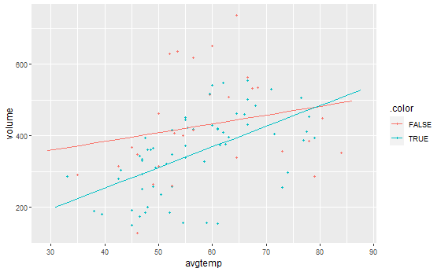

```r
plotModel(model4)
```

This looks promising! We reproduce our `ggplot` figure from earlier in this section.

Task - 2 mins Examine the summary of the model including the interaction between avgtemp and weekday. Is our inclusion of the interaction justified?

```r
model5 <- model5 <- lm(volume ~ avgtemp + weekday + cloudcover, data = railtrail_trim)

summary(model5)
```

```
Call:
lm(formula = volume ~ avgtemp + weekday + cloudcover, data = railtrail_trim)

Residuals:
     Min       1Q   Median       3Q      Max
-204.803  -58.375    6.594   60.178  277.581

Coefficients:
            Estimate Std. Error t value Pr(>|t|)
(Intercept) 200.1022    59.1826   3.381  0.00109 **
avgtemp       5.2461     0.9536   5.502 3.81e-07 ***
weekdayTRUE -47.9480    23.4061  -2.049  0.04356 *
cloudcover  -16.0115     3.3952  -4.716 9.21e-06 ***
---
Signif. codes:  0 ‘***’ 0.001 ‘**’ 0.01 ‘*’ 0.05 ‘.’ 0.1 ‘ ’ 1

Residual standard error: 100.3 on 86 degrees of freedom
Multiple R-squared:  0.4022,    Adjusted R-squared:  0.3814
F-statistic: 19.29 on 3 and 86 DF,  p-value: 1.185e-09
```

avgtemp 5.2461 = for each 1 degree of temp we have 5 more people

weekdayTRUE -47.9480 = have about 48 less people over the weekday than the weekend

cloudcover -16.0115 = for each 1 what ever of cloudcover we have 16 less people

Task - 5 mins Add precip (daily precipitation in inches) into the regression model. Perform diagnostics, and if you find that precip is a significant predictor, interpret its fitted coefficient.

```r
model6 <- model5 <- lm(volume ~ avgtemp + weekday + cloudcover +precip, data = railtrail_trim)

summary(model6)
```

```
Call:
lm(formula = volume ~ avgtemp + weekday + cloudcover + precip,
    data = railtrail_trim)

Residuals:
     Min       1Q   Median       3Q      Max
-218.881  -58.924    3.428   57.285  266.250

Coefficients:
             Estimate Std. Error t value Pr(>|t|)
(Intercept)  155.0024    59.4574   2.607 0.010787 *
avgtemp        5.8743     0.9485   6.193 2.02e-08 ***
weekdayTRUE  -45.8821    22.5943  -2.031 0.045412 *
cloudcover   -12.8294     3.4783  -3.688 0.000397 ***
precip      -117.5681    43.2329  -2.719 0.007928 **
---
Signif. codes:  0 ‘***’ 0.001 ‘**’ 0.01 ‘*’ 0.05 ‘.’ 0.1 ‘ ’ 1

Residual standard error: 96.72 on 85 degrees of freedom
Multiple R-squared:  0.4501,    Adjusted R-squared:  0.4242
F-statistic: 17.39 on 4 and 85 DF,  p-value: 1.849e-10
```

precip -117.5681 = for each 1 inch of precip we have 117 less people

```r
model7 <- model5 <- lm(volume ~ avgtemp + weekday  +precip, data = railtrail_trim)

summary(model7)
```

```
Call:
lm(formula = volume ~ avgtemp + weekday + precip, data = railtrail_trim)

Residuals:
    Min      1Q  Median      3Q     Max
-225.19  -65.22   10.41   51.64  262.85

Coefficients:
            Estimate Std. Error t value Pr(>|t|)
(Intercept)  108.075     62.191   1.738 0.085826 .
avgtemp        5.660      1.014   5.583  2.7e-07 ***
weekdayTRUE  -60.837     23.801  -2.556 0.012342 *
precip      -171.212     43.595  -3.927 0.000173 ***
---
Signif. codes:  0 ‘***’ 0.001 ‘**’ 0.01 ‘*’ 0.05 ‘.’ 0.1 ‘ ’ 1

Residual standard error: 103.6 on 86 degrees of freedom
Multiple R-squared:  0.362, Adjusted R-squared:  0.3398
F-statistic: 16.27 on 3 and 86 DF,  p-value: 1.848e-08
```

# Interaction of continuous predictors

```r
model7 <-  lm(volume ~ avgtemp + weekday + cloudcover + precip +
                avgtemp:precip, data = railtrail_trim)

summary(model7)
```

```
Call:
lm(formula = volume ~ avgtemp + weekday + cloudcover + precip +
    avgtemp:precip, data = railtrail_trim)

Residuals:
     Min       1Q   Median       3Q      Max
-218.775  -59.164    3.183   57.361  266.189

Coefficients:
                Estimate Std. Error t value Pr(>|t|)
(Intercept)     153.9280    63.9007   2.409 0.018189 *
avgtemp           5.8964     1.0598   5.564 3.08e-07 ***
weekdayTRUE     -45.8527    22.7365  -2.017 0.046921 *
cloudcover      -12.8866     3.6984  -3.484 0.000786 ***
precip         -100.8213   353.3547  -0.285 0.776097
avgtemp:precip   -0.2335     4.8893  -0.048 0.962023
---
Signif. codes:  0 ‘***’ 0.001 ‘**’ 0.01 ‘*’ 0.05 ‘.’ 0.1 ‘ ’ 1

Residual standard error: 97.29 on 84 degrees of freedom
Multiple R-squared:  0.4501,    Adjusted R-squared:  0.4173
F-statistic: 13.75 on 5 and 84 DF,  p-value: 8.34e-10
```

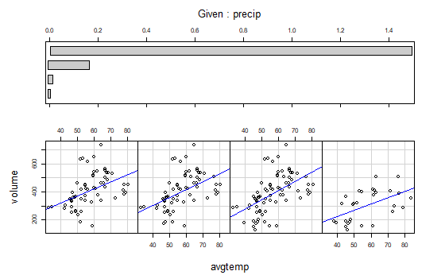

```r
coplot(volume ~ avgtemp | precip,
       rows = 1,
       panel = function(x, y, ...){
         points(x, y)
         abline(lm(y ~ x), col = "blue")
       },
       data = railtrail_trim)
```